# Welfare Survey Analysis: BART

Austin Murphy

6/3/2020

Studying the Welfare data.

More info: http://gss.norc.org/Documents/reports/social-change-reports/SC61%20GSS_Trends%20in%20Spending_1973-2016.pdf

Variable info: https://gssdataexplorer.norc.org/variables/vfilter

**Covariates** Description of some of the covariates: - `wrkstat`: Labor force status: Last week were you working full time, part time, going to school, keeping house, or what? - `prestg80`: Respondents occupational prestige score (1980) - `hompop`: Number of people in the household

**Race questions** On the average (Negroes/Blacks/African-Americans) have worse jobs, income, and housing than white people. Do you think these differences are

- `racdif1`: Mainly due to discrimination?
- `racdif2`: Because most (Negroes/Blacks/African-Americans) have less in-born ability to learn?
- `racdif3`: Because most (Negroes/Blacks/African-Americans) don’t have the chance for education that it takes to rise out of poverty?
- `racdif4`: Because most (Negroes/Blacks/African-Americans) just don’t have the motivation or will power to pull themselves up out of poverty? attblack is an average of the four variables above.

**Outcome Variables** Questions associated with this variable: We are faced with many problems in this country, none of which can be solved easily or inexpensively. I’m going to name some of these problems, and for each one I’d like you to name some of these problems, and for each one I’d like you to tell me whether you think we’re spending too much money on it, too little money, or about the right amount. First (READ ITEM A) . . . are we spending too much, too little, or about the right amount on (ITEM)?

- `natfare`: Welfare vs assistance to the poor. This is the name of the variable on the GSS website converted into Y in this dataset.
- `natrace{y}`: Improving the conditions of Blacks vs Assistance to blacks

```r
# Downloading script
# df <- readr::read_csv(file = "https://raw.githubusercontent.com/gsbDBI/ExperimentData/master/Welfare/ProcessedData/welfarenolabel3.csv", na = character())
# readr::write_csv(df, here::here("data/welfare.csv"))

# Read in provided welfare data
df <- readr::read_csv(file = here::here("data","welfare.csv"), na = character())
# Read in additional survey data
black_assistance <- readr::read_csv(file = here::here("data","black_assistance.csv"))
df <-
  df %>%
  dplyr::left_join(black_assistance)

# Specify outcome, treatment, and covariate variable names to use
outcome_variable_name <- "y" # or y_race for the other outcome variable
treatment_variable_name <- "w"
covariate_names <- c("partyid", "polviews", "age", "educ", "year", "attblack")

# Combine all names
all_variables_names <- c(outcome_variable_name, treatment_variable_name, covariate_names)
df <- df[, which(names(df) %in% all_variables_names)]

# Rename variables
names(df)[names(df) == outcome_variable_name] <- "Y"
names(df)[names(df) == treatment_variable_name] <- "W"

dim(df)
```

```
## [1] 36501     8
```

```r
colnames(df)
```

```
## [1] "year"     "age"      "educ"     "partyid"  "polviews" "W"        "Y"
## [8] "attblack"
```

```r
head(df)
```

```
## # A tibble: 6 x 8
##    year   age  educ partyid polviews     W     Y attblack
##   <dbl> <dbl> <dbl>   <dbl>    <dbl> <dbl> <dbl>    <dbl>
## 1  1986    28    14       3        4     0     0    0.333
## 2  1986    54    16       6        6     0     1    0.5
## 3  1986    44    16       0        2     0     1    0.75
## 4  1986    77    14       0        4     0     0    0.5
## 5  1986    44    14       0        4     0     0    0.5
## 6  1986    47    10       1        1     0     0    0.5
```

```r
# Filter out missing data
df <-
  df %>%
  filter_all(all_vars(. != -999)) %>%
  filter(partyid != 7)

# polviews has some values that are 4.1220088 for no reason... remove those
is.wholenumber <-
    function(x, tol = .Machine$double.eps^0.5)  abs(x - round(x)) < tol
df <- df[is.wholenumber(df$polviews),]
```

```r
apply(df, 2, table)
```

```
## $year
##
## 1986 1988 1989 1990 1991 1993 1994 1996 1998 2000 2002 2004 2006 2008 2010
## 1380  937  925 1288  960 1025 1837 1813 1720 1712  845  861 1873 1238 1324
##
## $age
##
##  18  19  20  21  22  23  24  25  26  27  28  29  30  31  32  33  34  35  36  37
##  54 223 259 300 323 335 351 429 379 371 455 385 421 432 456 446 460 462 434 472
##  38  39  40  41  42  43  44  45  46  47  48  49  50  51  52  53  54  55  56  57
## 461 426 426 431 428 424 407 372 336 379 360 373 342 340 315 287 281 265 269 244
##  58  59  60  61  62  63  64  65  66  67  68  69  70  71  72  73  74  75  76  77
## 212 258 269 248 245 232 201 207 222 220 224 202 189 160 214 186 181 153 144 147
##  78  79  80  81  82  83  84  85  86  87  88  89
## 139 117 107  93  94  85  62  60  50  48  40 116
##
## $educ
##
##    0    1    2    3    4    5    6    7    8    9   10   11   12   13   14   15
##   30    6   36   39   53   83  199  168  594  508  736 1071 5872 1814 2481  977
##   16   17   18   19   20
## 2794  643  842  291  501
##
## $partyid
##
##    0    1    2    3    4    5    6
## 3066 3983 2341 2861 1886 3442 2159
##
## $polviews
##
##    1    2    3    4    5    6    7
##  560 2290 2518 7431 3145 3163  631
##
## $W
##
##    0    1
## 9793 9945
##
## $Y
##
##     0     1
## 14445  5293
##
## $attblack
##
##          0       0.25 0.33333334        0.5 0.66666669       0.75          1
##       2514       6995        714       6690        372       1810        643
```

```r
summary(df)
```

```
##       year           age             educ          partyid         polviews
##  Min.   :1986   Min.   :18.00   Min.   : 0.00   Min.   :0.000   Min.   :1.000
##  1st Qu.:1991   1st Qu.:32.00   1st Qu.:12.00   1st Qu.:1.000   1st Qu.:3.000
##  Median :1996   Median :43.00   Median :13.00   Median :3.000   Median :4.000
##  Mean   :1997   Mean   :45.89   Mean   :13.25   Mean   :2.784   Mean   :4.131
##  3rd Qu.:2004   3rd Qu.:58.00   3rd Qu.:16.00   3rd Qu.:5.000   3rd Qu.:5.000
##  Max.   :2010   Max.   :89.00   Max.   :20.00   Max.   :6.000   Max.   :7.000
##        W                Y             attblack
##  Min.   :0.0000   Min.   :0.0000   Min.   :0.0000
##  1st Qu.:0.0000   1st Qu.:0.0000   1st Qu.:0.2500
##  Median :1.0000   Median :0.0000   Median :0.3333
##  Mean   :0.5039   Mean   :0.2682   Mean   :0.3840
##  3rd Qu.:1.0000   3rd Qu.:1.0000   3rd Qu.:0.5000
##  Max.   :1.0000   Max.   :1.0000   Max.   :1.0000
```

```r
mean(df$Y[df$W == 0]) - mean(df$Y[df$W == 1])
```

```
## [1] 0.3333626
```

```r
# W==1: "Caring for the poor" wording
# W==0: "Welfare" wording.

janitor::tabyl(df, year, W) %>%
  arrange(year) %>%
  janitor::adorn_totals()
```

```
##   year    0    1
##   1986  686  694
##   1988  449  488
##   1989  450  475
##   1990  631  657
##   1991  475  485
##   1993  510  515
##   1994  926  911
##   1996  888  925
##   1998  838  882
##   2000  866  846
##   2002  411  434
##   2004  433  428
##   2006  940  933
##   2008  611  627
##   2010  679  645
##  Total 9793 9945
```

This doesn’t match up with the paper’s table, but it’s close.

The paper used a probit BART model to estimate CATE because the response is binary.

BART wants a `x.test` matrix to be passed in when training the model. According to the paper, for each value of the covariate of interest, you create two copy of the training set. For each copy, set the covariate of interest to the value in question and set the treatment indicator to 0 for one copy and 1 to the other.

To more easily create test matrices, we’ll create two copies for each level in which we’re interested.:

```r
create_test_matrix <- function(df, column_name, covariate_levels){
  # Get unique values
  # covariate_levels = unique(df[[column_name]][order(df[column_name])])
  num_levels = length(covariate_levels)
  treatment_values = c(0,1)
  # Create a 'design matrix', with each row representing the pair of covariate value and treatment value used in filling the test matrix
  # first column: covariate value, second column: treatment level
  test_design = cbind(rep(covariate_levels,each=2),
                      rep(treatment_values,times=num_levels))
  print(test_design)

  # prep 'test' data. Large matrix of size (num values of interest * 2 * N) x ncols
  n = nrow(df)
  test_bart = NULL
  for (i in 1:nrow(test_design)){
    test0 = train %>% select(-Y)
    test0[ , column_name] = test_design[i,1]
    test0[ , 'W'] = test_design[i,2]

    test_bart = rbind(test_bart,test0)
  }
  dim(test_bart)
  return(list(test_design, test_bart))
}
```

## Party ID (partyid)

```r
train <- df
column_name = "partyid"
table(df[[column_name]])
```

```
##
##    0    1    2    3    4    5    6
## 3066 3983 2341 2861 1886 3442 2159
```

```r
summary(df[[column_name]])
```

```
##    Min. 1st Qu.  Median    Mean 3rd Qu.    Max.
##   0.000   1.000   3.000   2.784   5.000   6.000
```

```r
covariate_values = seq(0,6)
print(covariate_values)
```

```
## [1] 0 1 2 3 4 5 6
```

```r
out <- create_test_matrix(df, column_name, covariate_levels = covariate_values)
```

```
##       [,1] [,2]
##  [1,]    0    0
##  [2,]    0    1
##  [3,]    1    0
##  [4,]    1    1
##  [5,]    2    0
##  [6,]    2    1
##  [7,]    3    0
##  [8,]    3    1
##  [9,]    4    0
## [10,]    4    1
## [11,]    5    0
## [12,]    5    1
## [13,]    6    0
## [14,]    6    1
```

```r
test_design = out[[1]]; test_bart = out[[2]]

# Train BART model
set.seed(1)
bart =  BART::pbart(x.train = as.data.frame(train %>% select(-Y)),
                    y.train = train$Y,
                    x.test = as.data.frame(test_bart),
                    nskip = 1000)
```

[output not shown]

A function to create the CATE estimates from the BART model output

```r
calculate_cate <- function(bart, test_design){
  ## turn z-scores into probabilities
  print("Transforming to probabilities")
  bart$prob.test <- pnorm(bart$yhat.test)
  ## average over the posterior samples
  batch_indices = seq(1, to=ncol(bart$prob.test)+1, length.out=nrow(test_design)+1)
  # save memory
  bart$yhat.test <- NULL


  print("Averaging each batch")
  avg_post_draws = as.data.frame(matrix(NA, 1000, length(batch_indices)-1))
  for (i in 1:(length(batch_indices)-1)){
    # Select the data from one 1000xN dataframe
    batch = bart$prob.test[ , batch_indices[i]:(batch_indices[i+1]-1) ]
    # average over the observations to get E[CATE]
    avg_batch = apply(batch, 1, mean)
    # sanity check: should be of length 1000
    length(avg_batch) == 1000

    avg_post_draws[, i] = avg_batch
  }
  dim(avg_post_draws) # should be 1000 x 2*number of point estimates

  # save memory
  bart$prob.test <- NULL

  print("Estimating CATEs")
  ## Summary dataframe for CATE, and lower and upper bound estimates
  covariate_levels = unique(test_design[,1])
  estimates = data.frame(matrix(NA, length(covariate_levels), 4))
  estimates[,1] = covariate_levels
  names(estimates) <- c("covariate_val","mean","low","high")
  # Loop through the posterior draws and calculate the difference between them.
  # Calculate average CATE and 95% posterior bands.
  for (i in 1:dim(estimates)[1]){
    covariate_val = 2*i-1
    cate = avg_post_draws[, covariate_val] - avg_post_draws[, covariate_val+1]
    cate = cate[order(cate)]
    estimates[i,"mean"] = mean(cate)
    estimates[i,"low"] = quantile(cate, 0.025)
    estimates[i,"high"] = quantile(cate, 0.975)
  }
  return(estimates)
}
```

Estimate on partyid

```r
estimates <- calculate_cate(bart=bart,
                            test_design=test_design)
```

```
## [1] "Transforming to probabilities"
## [1] "Averaging each batch"
## [1] "Estimating CATEs"
```

Let’s see how it looks:

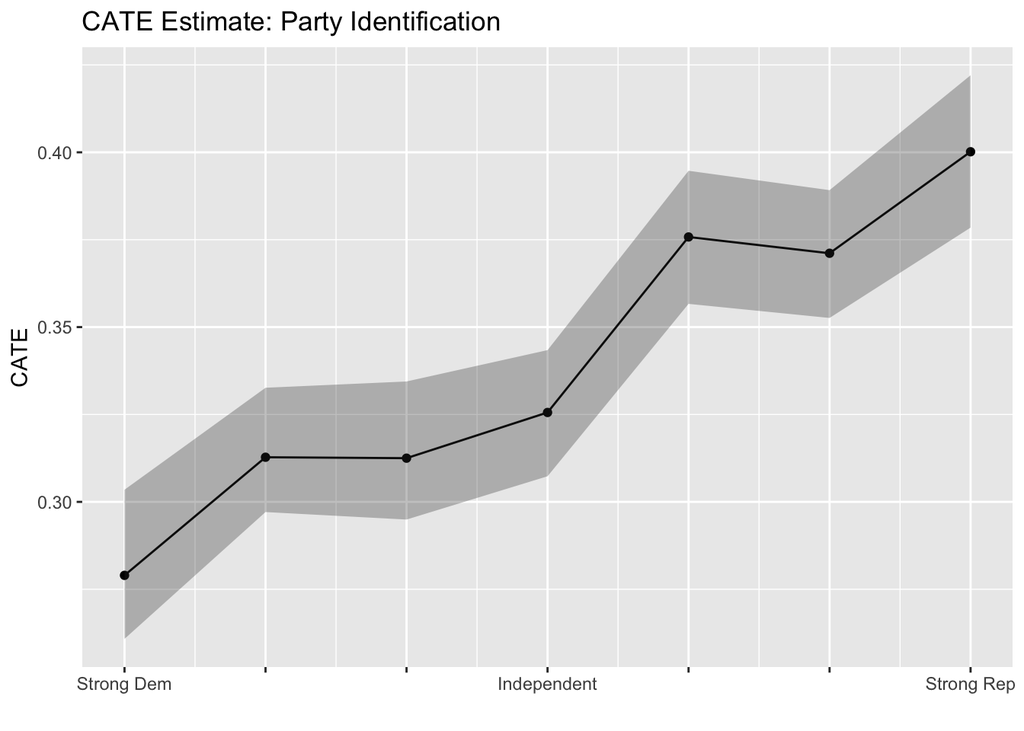

```r
# Plot the CATE estimates
ggplot(estimates, aes(x = covariate_val, y = mean)) +
  geom_line() +
  geom_point() +
  geom_ribbon(aes(ymin=low, ymax=high), alpha=0.3) +
  ggtitle("CATE Estimate: Party Identification") +
  xlab("") +
  ylab("CATE") +
  scale_x_continuous(breaks=covariate_values,
        labels=c("Strong Dem","","","Independent","","","Strong Rep"))
```

## Political Views

Now for Political Views (polviews)

```r
column_name = "polviews"
table(df[[column_name]])
```

```
##
##    1    2    3    4    5    6    7
##  560 2290 2518 7431 3145 3163  631
```

```r
summary(df[[column_name]])
```

```
##    Min. 1st Qu.  Median    Mean 3rd Qu.    Max.
##   1.000   3.000   4.000   4.131   5.000   7.000
```

```r
covariate_values = seq(1,7)
print(covariate_values)
```

```
## [1] 1 2 3 4 5 6 7
```

```r
out <- create_test_matrix(df, column_name, covariate_levels = covariate_values)
```

```
##       [,1] [,2]
##  [1,]    1    0
##  [2,]    1    1
##  [3,]    2    0
##  [4,]    2    1
##  [5,]    3    0
##  [6,]    3    1
##  [7,]    4    0
##  [8,]    4    1
##  [9,]    5    0
## [10,]    5    1
## [11,]    6    0
## [12,]    6    1
## [13,]    7    0
## [14,]    7    1
```

```r
test_design = out[[1]]; test_bart = out[[2]]

# Train BART model
rm(bart)
set.seed(1)
bart =  BART::pbart(x.train = as.data.frame(train %>% select(-Y)),
                    y.train = train$Y,
                    x.test = as.data.frame(test_bart),
                    nskip = 1000)
```

[output not shown]

```r
estimates <- calculate_cate(bart=bart,
                            test_design=test_design)
```

```
## [1] "Transforming to probabilities"
## [1] "Averaging each batch"
## [1] "Estimating CATEs"
```

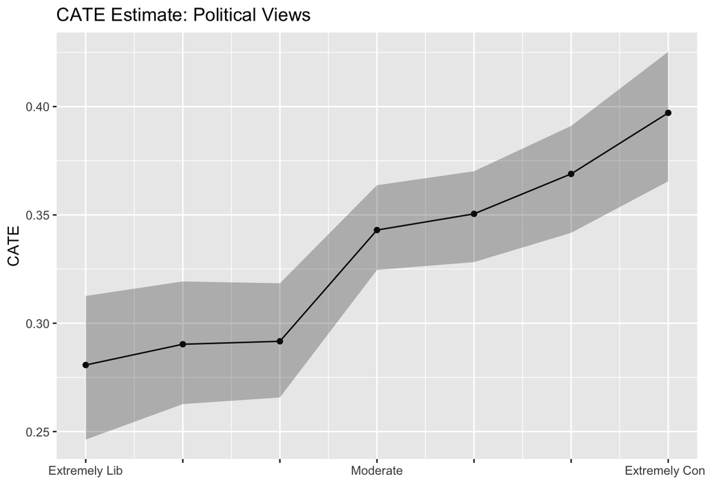

```r
# Plot the CATE estimates
ggplot(estimates, aes(x = covariate_val, y = mean)) +
  geom_line() +
  geom_point() +
  geom_ribbon(aes(ymin=low, ymax=high), alpha=0.3) +
  ggtitle("CATE Estimate: Political Views") +
  xlab("") +
  ylab("CATE") +
  scale_x_continuous(breaks=covariate_values,
        labels=c("Extremely Lib","","","Moderate","","","Extremely Cons"))
```

## Age

Now for Age (age)

```r
column_name = "age"
table(df[[column_name]])
```

```
##
##  18  19  20  21  22  23  24  25  26  27  28  29  30  31  32  33  34  35  36  37
##  54 223 259 300 323 335 351 429 379 371 455 385 421 432 456 446 460 462 434 472
##  38  39  40  41  42  43  44  45  46  47  48  49  50  51  52  53  54  55  56  57
## 461 426 426 431 428 424 407 372 336 379 360 373 342 340 315 287 281 265 269 244
##  58  59  60  61  62  63  64  65  66  67  68  69  70  71  72  73  74  75  76  77
## 212 258 269 248 245 232 201 207 222 220 224 202 189 160 214 186 181 153 144 147
##  78  79  80  81  82  83  84  85  86  87  88  89
## 139 117 107  93  94  85  62  60  50  48  40 116
```

```r
summary(df[[column_name]])
```

```
##    Min. 1st Qu.  Median    Mean 3rd Qu.    Max.
##   18.00   32.00   43.00   45.89   58.00   89.00
```

```r
covariate_values = seq(18,89,by=5)
print(covariate_values)
```

```
##  [1] 18 23 28 33 38 43 48 53 58 63 68 73 78 83 88
```

```r
out <- create_test_matrix(df, column_name, covariate_levels = covariate_values)
```

```
##       [,1] [,2]
##  [1,]   18    0
##  [2,]   18    1
##  [3,]   23    0
##  [4,]   23    1
##  [5,]   28    0
##  [6,]   28    1
##  [7,]   33    0
##  [8,]   33    1
##  [9,]   38    0
## [10,]   38    1
## [11,]   43    0
## [12,]   43    1
## [13,]   48    0
## [14,]   48    1
```

[output cut: 16 more lines]

```r
test_design = out[[1]]; test_bart = out[[2]]

# Train BART model
rm(bart)
set.seed(1)
bart =  BART::pbart(x.train = as.data.frame(train %>% select(-Y)),
                    y.train = train$Y,
                    x.test = as.data.frame(test_bart),
                    nskip = 1000)
```

[output not shown]

```r
estimates <- calculate_cate(bart=bart,
                            test_design=test_design)
```

```
## [1] "Transforming to probabilities"
## [1] "Averaging each batch"
## [1] "Estimating CATEs"
```

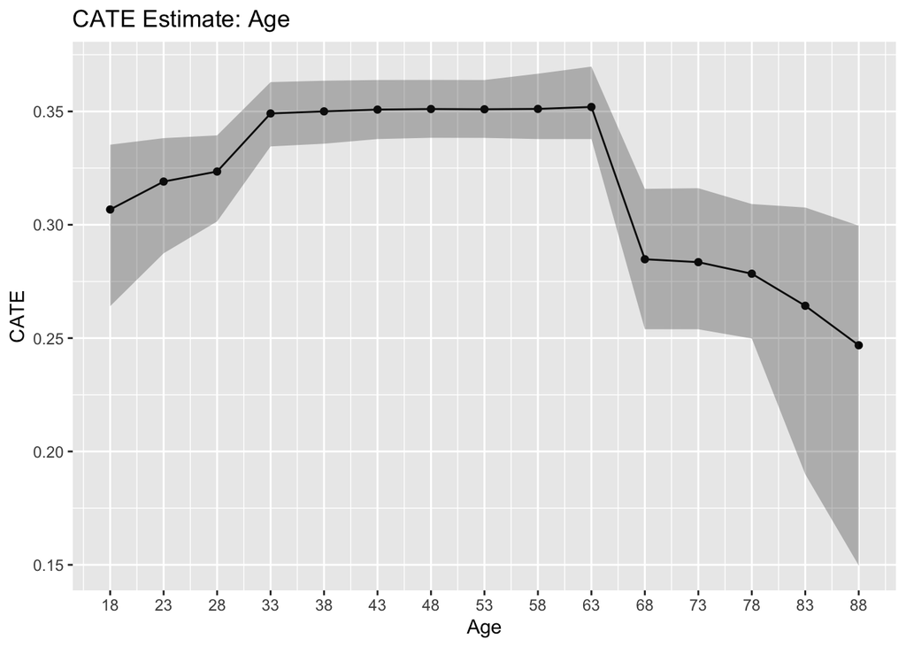

```r
# Plot the CATE estimates
ggplot(estimates, aes(x = covariate_val, y = mean)) +
  geom_line() +
  geom_point() +
  geom_ribbon(aes(ymin=low, ymax=high), alpha=0.3) +
  ggtitle("CATE Estimate: Age") +
  xlab("Age") +
  ylab("CATE") +
  scale_x_continuous(breaks=covariate_values,
        labels=covariate_values)
```

## Negative Attitude Towards Blacks

```r
column_name = "attblack"
table(df[[column_name]])
```

```
##
##          0       0.25 0.33333334        0.5 0.66666669       0.75          1
##       2514       6995        714       6690        372       1810        643
```

```r
summary(df[[column_name]])
```

```
##    Min. 1st Qu.  Median    Mean 3rd Qu.    Max.
##  0.0000  0.2500  0.3333  0.3840  0.5000  1.0000
```

```r
covariate_values = unique(df[[column_name]])[order(unique(df[[column_name]]))]
print(covariate_values)
```

```
## [1] 0.0000000 0.2500000 0.3333333 0.5000000 0.6666667 0.7500000 1.0000000
```

```r
out <- create_test_matrix(df, column_name, covariate_levels = covariate_values)
```

```
##            [,1] [,2]
##  [1,] 0.0000000    0
##  [2,] 0.0000000    1
##  [3,] 0.2500000    0
##  [4,] 0.2500000    1
##  [5,] 0.3333333    0
##  [6,] 0.3333333    1
##  [7,] 0.5000000    0
##  [8,] 0.5000000    1
##  [9,] 0.6666667    0
## [10,] 0.6666667    1
## [11,] 0.7500000    0
## [12,] 0.7500000    1
## [13,] 1.0000000    0
## [14,] 1.0000000    1
```

```r
test_design = out[[1]]; test_bart = out[[2]]

# Train BART model
rm(bart)
set.seed(1)
bart =  BART::pbart(x.train = as.data.frame(train %>% select(-Y)),
                    y.train = train$Y,
                    x.test = as.data.frame(test_bart),
                    nskip = 1000)
```

[output not shown]

```r
estimates <- calculate_cate(bart=bart,
                            test_design=test_design)
```

```
## [1] "Transforming to probabilities"
## [1] "Averaging each batch"
## [1] "Estimating CATEs"
```

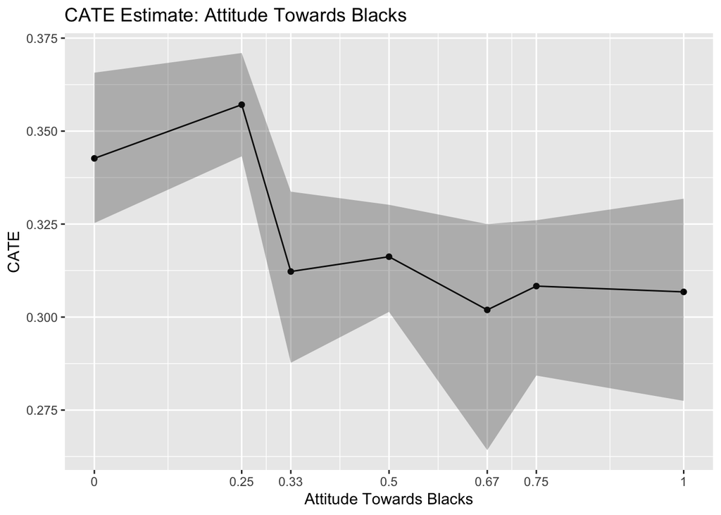

```r
# Plot the CATE estimates
ggplot(estimates, aes(x = covariate_val, y = mean)) +
  geom_line() +
  geom_point() +
  geom_ribbon(aes(ymin=low, ymax=high), alpha=0.3) +
  ggtitle("CATE Estimate: Attitude Towards Blacks") +
  xlab("Attitude Towards Blacks") +
  ylab("CATE") +
  scale_x_continuous(breaks=covariate_values,
        labels=round(covariate_values,2))
```